DS 6030 | Fall 2024 | University of Virginia

# Homework #6: SVM and Calibration

Author

**SOLUTIONS**

Published

Fall 2024

**Warning**

These solutions are only for the private use of the students of DS 6030 Fall 2024. Sharing of the solutions, posting on the internet, selling to a company, or possession by anyone outside of the class constitutes a violation of the honor policy.

# Required R packages and Directories

```r
dir_data= 'https://mdporter.github.io/teaching/data/' # data directory
library(knitr)      # for nicer printing of tables with kable
library(e1071)      # for SVM
library(tidymodels) # for modeling and evaluation functions
library(tidyverse)  # functions for data manipulation
```

# COMPAS Recidivism Prediction

A recidivism risk model called COMPAS was the topic of a [ProPublica article](https://www.propublica.org/article/machine-bias-risk-assessments-in-criminal-sentencing/) on ML bias. Because the data and notebooks used for article was released on [github](https://github.com/propublica/compas-analysis), we can also evaluate the prediction bias (i.e., calibration).

This code will read in the *violent crime* risk score and apply the filtering used in the [analysis](https://github.com/propublica/compas-analysis/blob/master/Compas%20Analysis.ipynb).

```r
library(tidyverse)
df = read_csv("https://raw.githubusercontent.com/propublica/compas-analysis/master/compas-scores-two-years-violent.csv")

risk = df %>%
  filter(days_b_screening_arrest <= 30) %>%
  filter(days_b_screening_arrest >= -30) %>%
  filter(is_recid != -1) %>%
  filter(c_charge_degree != "O") %>%
  filter(v_score_text != 'N/A') %>%
  transmute(
    age, age_cat,
    charge = ifelse(c_charge_degree == "F", "Felony", "Misdemeanor"),
    race,
    sex,
    priors_count = priors_count...15,
    score = v_decile_score,              # the risk score {1,2,...,10}
    outcome = two_year_recid...53        # outcome {1 = two year recidivate}
  )
```

The `risk` data frame has the relevant information for completing the problems.

# Problem 1: COMPAS risk score

## a. Risk Score and Probability (table)

Assess the predictive bias in the COMPAS risk scores by evaluating the probability of recidivism, e.g. estimate $\Pr(Y = 1 \mid \text{Score}=x)$. Use any reasonable techniques (including Bayesian) to estimate the probability of recidivism for each risk score.

Specifically, create a table (e.g., data frame) that provides the following information:

- The COMPASS risk score.
- The point estimate of the probability of recidivism for each risk score.
- 95% confidence or credible intervals for the probability (e.g., Using normal theory, bootstrap, or Bayesian techniques).

Indicate the choices you made in estimation (e.g., state the prior if you used Bayesian methods).

**Solution**

I’ll just use the normal approach to using sample proportions and confidence intervals.

```r
risk_table = risk %>%
  group_by(score) %>%
    summarize(
      n = n(),
      n_recid = sum(outcome == 1),
      p = mean(outcome == 1),
      moe = 2*sqrt(p*(1-p)/n),
      lower = p - moe,
      upper = p + moe
    ) %>%
  ungroup()
```

```r
risk_table %>%
  transmute(
    score, n,
    p_recid = round(p, 2),
    CI = str_c("(", round(p-moe, 2), ", ", round(p+moe, 2), ")")
  ) %>% kable()
```

| score | n | p_recid | CI |
| --- | --- | --- | --- |
| 1 | 1340 | 0.06 | (0.05, 0.08) |
| 2 | 622 | 0.09 | (0.07, 0.12) |
| 3 | 543 | 0.17 | (0.14, 0.2) |
| 4 | 408 | 0.18 | (0.14, 0.21) |
| 5 | 325 | 0.18 | (0.14, 0.23) |
| 6 | 300 | 0.28 | (0.23, 0.34) |
| 7 | 203 | 0.32 | (0.25, 0.38) |
| 8 | 122 | 0.43 | (0.34, 0.52) |
| 9 | 110 | 0.56 | (0.47, 0.66) |
| 10 | 47 | 0.47 | (0.32, 0.61) |

Notice that the above approach is a 10 parameter model: we estimated the probability for each risk score. This is very suitable when we have lots of data. But when the number of observations per score gets smaller it will be better to use a model with less complexity. This is usually accomplished through using a less complex model structure (e.g., logistic regression) or with regularization (e.g., penalties or Bayesian).

### Modeling Alternative Approach

As an alternative, we could have tried logistic regression using the `score` as the predictor variable. Since a edf=2 model is probably too restrictive (since we want to see the patterns), I’ll use a edf=6 parameter bspline (df=5 + 1 intercept).

```r
library(splines)
log_reg = glm(outcome ~ splines::bs(score, df=5),
              family = "binomial",
              data = risk)

risk_table_log_reg = tibble(score = 1:10) %>%
  broom::augment(log_reg, newdata = ., type.predict = "response", se_fit = TRUE) %>%
  mutate(
    lower = .fitted - 2*.se.fit,
    upper = .fitted + 2*.se.fit
  )


risk_table_log_reg %>%
  transmute(
    score,
    p_recid = round(.fitted, 2),
    CI = str_c("(", round(lower, 2), ", ", round(upper, 2), ")")
  ) %>% kable()
```

| score | p_recid | CI |
| --- | --- | --- |
| 1 | 0.06 | (0.05, 0.08) |
| 2 | 0.09 | (0.07, 0.12) |
| 3 | 0.17 | (0.14, 0.2) |
| 4 | 0.17 | (0.15, 0.2) |
| 5 | 0.20 | (0.17, 0.22) |
| 6 | 0.26 | (0.23, 0.29) |
| 7 | 0.35 | (0.31, 0.39) |
| 8 | 0.45 | (0.39, 0.5) |
| 9 | 0.51 | (0.45, 0.58) |
| 10 | 0.51 | (0.38, 0.64) |

We could use resampling (e.g., cross-validation, bootstrap) or AIC/BIC to select the optimal edf for the splines.

## b. Risk Score and Probability (plot)

Make a plot of the risk scores and corresponding estimated probability of recidivism.

- Put the risk score on the x-axis and estimate probability of recidivism on y-axis.
- Add the 95% confidence or credible intervals calculated in part a.
- Comment on the patterns you see.

**Solution**

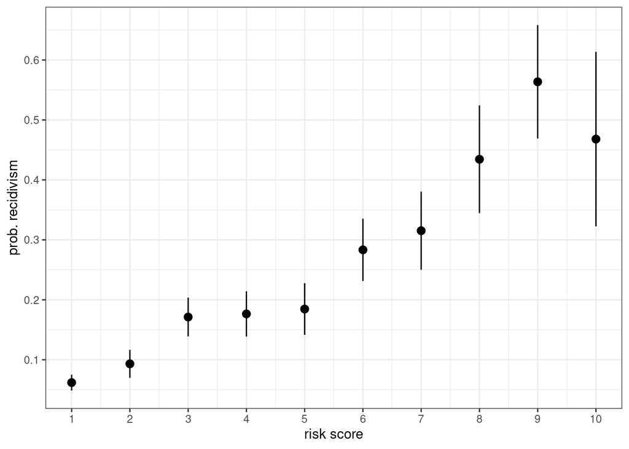

```r
risk_table %>%
  ggplot(aes(score, p)) +
  geom_point() +
  geom_pointrange(aes(ymin=lower, ymax=upper)) +
  scale_x_continuous(breaks = 1:10) +
  scale_y_continuous(breaks = seq(0, 1, by = .1)) +
  labs(x = "risk score", y = "prob. recidivism")
```

Here are a few things I notice:

- The lowest risk score still has over 5% recidivism.
- The highest risk has an estimated 30%-60% recidivism rate.
- In general, the higher the risk score the higher the recidivism rate. But,
  - Risk scores 3-5 look very similar in actual risk.
  - The downward trend with risk score of 10 has a lot of uncertainty, so it isn’t clear that it is a true pattern.

What patterns did you note? Anything concerning?

Coming back to the non-linear logistic regression approach:

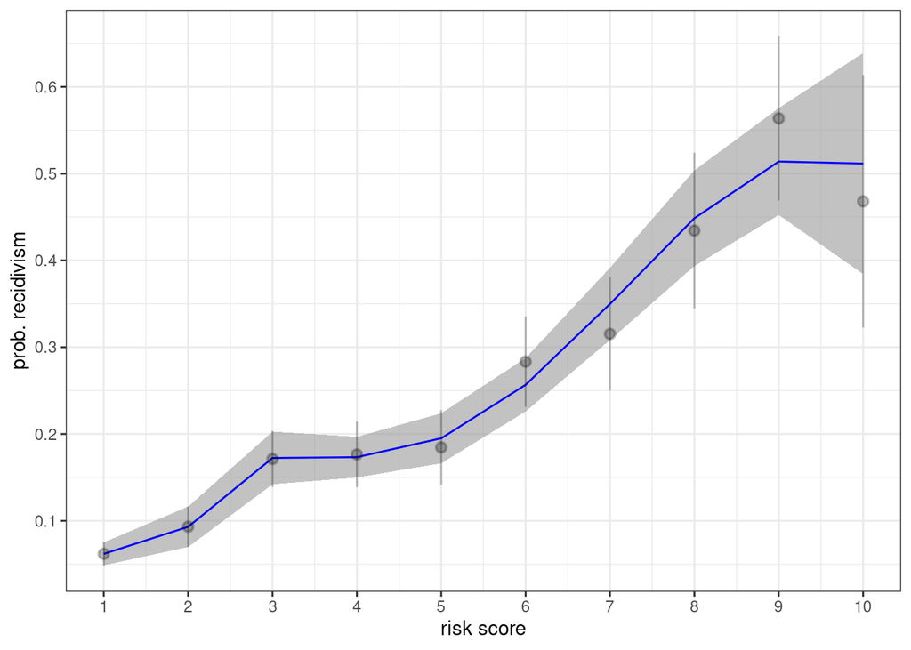

```r
risk_table_log_reg %>%
ggplot(aes(score, .fitted)) +
  geom_ribbon(aes(ymin = .fitted- 2*.se.fit, ymax = .fitted + 2*.se.fit),
              fill = "grey60", alpha = .6) +
  geom_line(color = "blue") +
  scale_x_continuous(breaks = 1:10) +
  scale_y_continuous(breaks = seq(0, 1, by = .1)) +
  labs(x = "risk score", y = "prob. recidivism") +
  geom_pointrange(data = risk_table, aes(y = p, ymin=lower, ymax=upper),
                  alpha = .25)
```

I overlaid the 10 parameter model for comparison. Not too different in information, however the lines help you see the “smoothness” in the estimates.

```r
##: this produces an equivalent plot
# ggplot(risk, aes(score, outcome)) +
#   geom_smooth(
#     method = "glm",
#     method.args = list(family = "binomial"),
#     formula = y ~ splines::bs(x, df=5)) +
#   scale_x_continuous(breaks = 1:10) +
#   scale_y_continuous(breaks = seq(0, 1, by = .1)) +
#   labs(x = "risk score", y = "prob. recidivism")
```

## c. Risk Score and Probability (by race)

Repeat the analysis, but this time do so for every race. Produce a set of plots (one per race) and comment on the patterns.

**Solution**

If we use the same approach that we used in the previous problem, we will get some bad estimates when there are few observations per score.

```r
risk_table_race = risk %>%
  group_by(race, score) %>%
    summarize(
      n = n(),
      n_recid = sum(outcome == 1),
      p = mean(outcome == 1),
      moe = 2*sqrt(p*(1-p)/n),
      lower = pmax(p - moe, 0),
      upper = pmin(p + moe, 1),
      .groups = "drop"
    ) %>%
  ungroup()
```

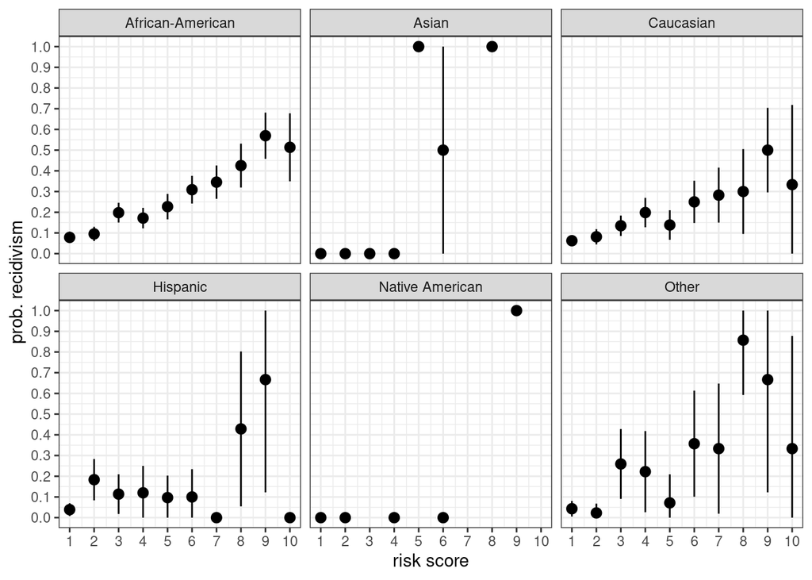

```r
risk_table_race %>%
  ggplot(aes(score, p)) +
  geom_pointrange(aes(ymin=lower, ymax=upper)) +
  scale_x_continuous(breaks = 1:10) +
  scale_y_continuous(breaks = seq(0, 1, by = .1)) +
  labs(x = "risk score", y = "prob. recidivism") +
  facet_wrap(~race)
```

This approach seems ok for African-American and Caucasian, but there are not enough observations for the other races to show anything meaningful.

Remember the Laplace smoothing idea that uses pseudo-observations? This estimate can be seen as the posterior mean from a Beta distribution. Here’s one way to implement:

1. Set the number of pseudo-recidivists and pseudo-non-recidivists for each risk score. This specifies the prior probability for a given risk score is $\text{Beta}(a_x, b_x)$, where $a_x$ ($b_x$) can be viewed as the prior number of recidivists (non-recidivists) for risk score $x$. I’ll break this into the two steps below:
2. Specify the prior recidivism probability for each risk score as the proportion of recidivism averaged over all races (i.e., the model from *a*).
   - This is going to have the effect of shrinking all race-based estimates toward the common average. Is this a good model? I don’t know. We could alternatively specify a different relationship.
   - Note: this uses the training data to estimate the prior, so isn’t really a proper Bayesian treatment. But sufficient for our exploratory analysis.
3. Set the strength of the prior. This corresponds to the total number of pseudo-observations. Here I use the notation $k_x = a_x + b_x$.
4. The corresponding posterior distribution is $\text{Beta}(n_{1x} + a_x, n_{0x} + b_x)$, from which we can get the credible intervals. The $n_{1x}$ is number of recidivisms for people with risk score $x$.

```r
#: estimate overall probability by score (average over all races)
prior = risk_table %>% select(score, prior = p)

#: set strength of prior (number of pseudo-observations)
k = 2

#: combine prior and observed data
risk_table_race_posterior = risk_table_race %>%
  complete(race, score, fill = list(n=0, n_recid=0, p=0)) %>%
  left_join(prior, by = "score") %>%
  mutate(
    a = k*prior,      # number of pseudo-recidivisms
    b = k*(1-prior),  # number of pseudo-non-recidvisms
    posterior_mu = (n_recid + a) / (n + k),
    lower = qbeta(.025, n_recid + a, n-n_recid + b),
    upper = qbeta(.975, n_recid + a, n-n_recid + b)
  )

risk_table_race_posterior
```

```
# A tibble: 60 × 12
  race         score     n n_recid      p    moe  lower upper  prior     a     b
  <chr>        <dbl> <int>   <int>  <dbl>  <dbl>  <dbl> <dbl>  <dbl> <dbl> <dbl>
1 African-Ame…     1   395      31 0.0785 0.0271 0.0541 0.107 0.0619 0.124  1.88
2 African-Ame…     2   294      28 0.0952 0.0342 0.0645 0.131 0.0932 0.186  1.81
3 African-Ame…     3   278      55 0.198  0.0478 0.153  0.246 0.171  0.343  1.66
4 African-Ame…     4   233      40 0.172  0.0494 0.126  0.222 0.176  0.353  1.65
5 African-Ame…     5   185      42 0.227  0.0616 0.170  0.289 0.185  0.369  1.63
6 African-Ame…     6   191      59 0.309  0.0669 0.246  0.375 0.283  0.567  1.43
# ℹ 54 more rows
# ℹ 1 more variable: posterior_mu <dbl>
```

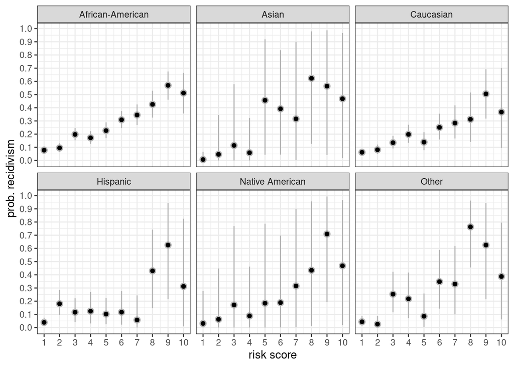

```r
risk_table_race_posterior %>%
ggplot(aes(score, posterior_mu)) +
  geom_pointrange(aes(ymin=lower, ymax=upper), color = "grey70") +
  geom_point() +
  scale_x_continuous(breaks = 1:10) +
  scale_y_continuous(breaks = seq(0, 1, by = .1)) +
  labs(x = "risk score", y = "prob. recidivism") +
  facet_wrap(~race)
```

This didn’t help much, but does tend to help prevent misunderstanding when communicating the uncertainty in estimates from small data. We could increase the strength of the prior, but that will enforce stronger assumptions; something I’m not wanting to do for this exploratory analysis.

What do I see? The recidivism rates for the African-American and Caucasian follow a common trend. The Hispanic population does not seem to be well calibrated. While uncertainty is still high, there is evidence that risk score of 1-7 have the same recidivism rate. Hard to say much for the other races due to the high uncertainty.

## d. ROC Curves

Use the raw COMPAS risk scores to make a ROC curve for each race.

- Are the best discriminating models the ones you expected?
- Are the ROC curves helpful in evaluating the COMPAS risk score?

**Solution**

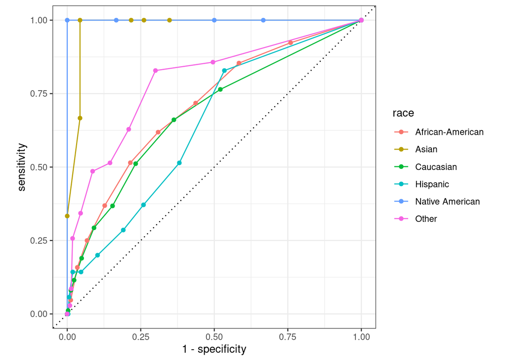

```r
library(tidymodels)
risk %>%
  mutate(outcome = factor(outcome, c(1,0))) %>%
  group_by(race) %>%
  roc_curve(outcome, score) %>%
  autoplot() +
  geom_point(aes(1-specificity, sensitivity, color=race))
```

For good measure, here are the AUC

```r
risk %>%
  mutate(outcome = factor(outcome, c(1,0))) %>%
  group_by(race) %>%
  roc_auc(outcome, score) %>%
  select(race, auc = .estimate) %>%
  arrange(-auc)
```

```
# A tibble: 6 × 2
  race               auc
  <chr>            <dbl>
1 Native American  1
2 Asian            0.978
3 Other            0.792
4 African-American 0.708
5 Caucasian        0.683
6 Hispanic         0.641
```

We see that risk scores that have the most discrimination are for the the races with the fewest observations (*Native American* and *Asian*).

```r
risk %>% count(race) %>% arrange(n)
```

```
# A tibble: 6 × 2
  race                 n
  <chr>            <int>
1 Native American      7
2 Asian               26
3 Other              255
4 Hispanic           355
5 Caucasian         1459
6 African-American  1918
```

This may be misleading for a few reasons. First, the uncertainty in the ROC curves is very large-this is not represented in the lines. Second, we see that the ROC curves and AUC don’t necessarily reflect calibration. A model may have decent *discrimination*, but the estimated probabilities are far from the real values.

# Problem 2: Support Vector Machines (SVM)

Focus on Problem 1, we won’t have an SVM problem this week.